# Виды анализа и R Markdown

> Способность к анализу не следует смешивать с простой изобретательностью, ибо аналитик всегда изобретателен, тогда как не всякий изобретательный человек способен к анализу.

*Эдгар Аллан По, Убийство на улице Морг*

# Введение

Цель данной работы - привести **примеры научных работ**, в которых использовались конкретные **виды анализа** и обосновать корректность подобранных примеров. Виды анализа для моего варианта:

1. Дедуктивный (Логический)
2. Механистический

Также необходимо продемонстрировать умение пользоваться языком разметки **R Markdown**. Для этого данная работа должна быть создана с его помощью и содержать следующие элементы:

- заголовки разных уровней
- маркированные списки
- нумерованные списки
- URL-ссылки
- математические формулы в формате LaTeX
- изображения
- цитаты
- таблицы

Пойдем по порядку.

# Виды анализа

Сегодня человеческая цивилизация генерирует колоссальные объемы данных, которые необходимо постоянно анализировать. Основная цель любого анализа данных – **поиск и обнаружение закономерностей** в объеме данных. Однако наборы данных бывают разные. Они отличаются объемом данных, типом и количеством показателей, полнотой, зашумленностью, описываемыми явлениями. Для разных наборов данных существуют различные виды их анализа.

В рамках курса “Методы очистки данных” были описаны 6 видов анализа данных:

1. Дескриптивный (Описательный)
2. Разведочный
3. Дедуктивный (Логический)
4. Прогностический
5. Причинно-следственный
6. Механистический

В данной работе я затрону №3 и №6.

## Дедуктивный анализ

### Описание

Данный вид анализа подразумевает **экстраполяцию выводов** о малой выборке на всю совокупность. Особенности дедуктивного анализа:

- Позволяет оценить значение переменной для генеральной совокупности и указывает меру неопределенности полученной оценки
- Точность выводов сильно зависит схемы выборки (выборка должна быть репрезентативна)

### Пример

**Мониторинг воздействия на здоровье человека производственно-технических факторов**

[DOI: 10.24411/1728-323X-2019-18033](https://www.doi.org/10.24411/1728-323X-2019-18033)

В данной работе авторы исследуют влияние неблагоприятных факторов литейного производства на организм рабочих. В исследовании принимали участие 80 рабочих и контрольная группа из 50 здоровых людей. Рабочих разделили на 3 группы по продолжительности работы на производстве:

| № Группы | Стаж работы, г | Количество участников, чел | Количество участников, % |
| --- | --- | --- | --- |
| 1 | 1 - 5 | 26 | 32,5 |
| 2 | 5 - 10 | 32 | 40,0 |
| 3 | 10 - 15 | 22 | 27,5 |

Рабочие были обследованы на наличие различных групп заболеваний. Большая часть рабочих *(62,30%)* имела заболевания органов пищеварения. Диагностика микрофлоры кишечника рабочих показала негативные отклонения от контрольной группы, выраженные в уменьшениии встречаимости соответствующих бактерий *(бифидобактерий, пропионобактерий лактобактерий, бактероидов)*. Важно, что отклонение увеличивалось от 1 к 3 группе. Также обнаружилось, что увеличивается встречаемость паразитов **Blastocystis spp.** от 1 к 3 группе.

Дальнейший анализ показал, что данный вид паразитов можно использовать как биологический индикатор состояния мкрофлоры кишечника человека, работающего на литейном производстве.

Выводы о выборке объемом в 80 случаев были экстраполированы на совокупность всех рабочих литейных производств. Таким образом можно убедиться в использовании **дедуктивного анализа** в данном исследовании.

## Механистический анализ

### Описание

Выявление **точной зависимости** одних величин от других выделяет механистический анализ среди прочих видов анализа. Особенности механистического анализа:

- Данному виду анализа хорошо подходит термин “моделирование”
- Применяется к ситуациям, которые хорошо моделируются детерменированными уравнениями
- Обычно примениется к физическим и инженерным наукам (где скрытые зависимости мало влияют на объекты)
- Часто единственный шум в данных - ошибки измерения

### Пример

**Надежность изделий из полимерных композиционных материалов с учетом статистической изменчивости их характеристик**

[CyberLeninka](https://cyberleninka.ru/article/n/nadezhnost-izdeliy-iz-polimernyh-kompozitsionnyh-materialov-s-uchetom-statisticheskoy-izmenchivosti-ih-harakteristik)

Данная работа посвящена изучению надежности полимерных компазиционных материалов на основе полипропилена. Надежность оценивают с помощью вероятность безотказной работы $R$, которая раcсчитывается по формуле:

$$R = 1 - \Phi \Bigg[ \frac{\bar{\sigma}_{пт} - \bar{\sigma}_{экн}}{\sqrt{S_{\sigma_{пт}}^2 + S_{\sigma_{экн}}^2}} \Bigg]$$

, где $\bar{\sigma}_{пт}$ и $\bar{\sigma}_{экн}$ - среднее значение предела текучести при растяжении и среднее значение эквивалентного напряжения соответственно, $S_{\sigma_{пт}}^2$ и $S_{\sigma_{экн}}^2$ - среднее квадратическое отклонение предела текучести при растяжении и среднее квадратическое отклонение эквивалентного напряжения соответственно.

В данной работе оценивается влияние различных параметров на надежность (и другие величины в процессе анализа). Моделируются различные ситуации, условия работы и режимы экспуатации. Строятся графики зависимостей одних величин от других.

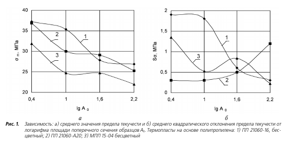

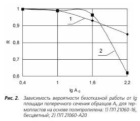

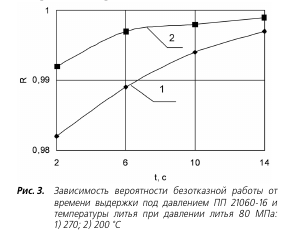

В данном исследовании выявлена точная зависимость надежности изделий из полимерных композиционных материалов от условий работы и параметров изделия, а значит использовался **механистический анализ**.

# Заключение

В ходе работы были подобраны и обоснованы примеры для интересующих **видов анализа**, а также с помощью **R Markdown** был создан этот документ с внедрением необходимых структурных элементов.

[Репозиторий проекта на GitHub.](https://github.com/Erik-s45/RMarkdawn)